# Analysis of Intervention

Doynikov A

April 20, 2021

# Анализ Интервенций

Интервенция - резкое внешнее воздействие на динамику временного ряда. Впервые модель интервеций предложена Бокс и Тяо(Box,Tiao) в 1975 году. Посмотрим на график логарифмов авиа миль на пассажира из библиотеки TSA

```r
library(TSA)
```

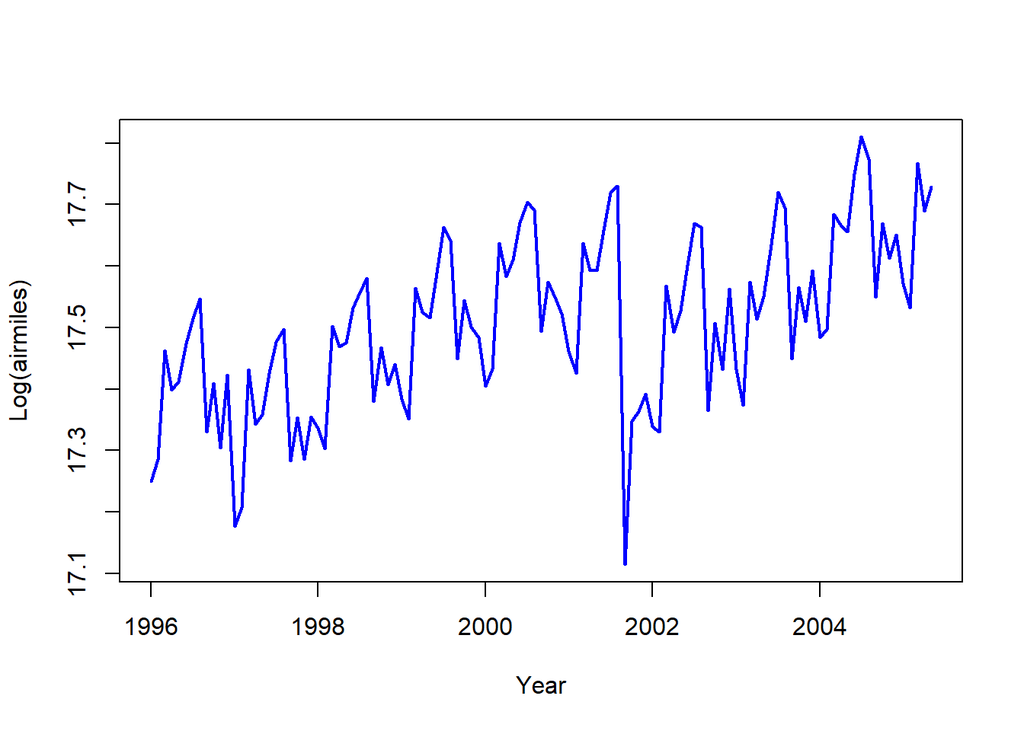

```r
data(airmiles)
plot(log(airmiles),ylab = 'Log(airmiles)' ,xlab ='Year',lwd=2,col='blue')
```

Сначала рассмотрим такую модель

$y_t= m_t+N_t$

здесь $m_t$ - функция изменения среднего, $N_t$ - процесс (взможно ARMA сезонный) без интервенций. Предположим интервеция произшла в момент T. До момента T разумно $m_t$ положить 0. $y_t,t <T$ процесс до интервеции. Интервенцию будем строить с помощью функции ступенька

$m_t = \omega S_t(T)$

, где параметр $\omega$ подлежит оценке. Если интервенция имеет не мгновенное, а растянутое по времени действие, то это моделируют процессом возможно типа авторегрессии AR(p). Начнем с авторегрессии первого порядка

$$m_t= \delta m_{t-1}+\omega S_{t-1}(T)$$
с начальным условием $m_0=0$. После простейших преобразований это можно переписать как

$$m_t=\omega\frac{1-\delta^{t-T}}{1-\delta}$$
при $t>T$ иначе $m_t= 0$

где обычно предполагается, что $\delta <1$.

В Случае$\delta =1$ $m_t=\omega(T-t)$ при $t>T$ и 0 иначе.

Аналогично с переменной типа ступенька

$m_t = \omega P_t(T)$

$m_t= \delta m_{t-1}+\omega P_{t-1}(T)$ (*)

что после преобразований $m_t=\omega\delta^{t-T}$ при $t>=T$

Удобно использовать оператор сдвига $Bm_t=m_{t-1}, BP_t(T)=P_{t-1}(T)$

В частности моель (*) можно переписать так
$$m_t(1-\delta B)= \omega BP_{t}(T)$$

или

$$m_t=\frac{\omega B}{(1-\delta B)}P_{t}(T)$$

Также заметим, что $S_t(T)= \frac{1}{1-B}P_t(T)$ поэтому модель можно записывать как с переменной типа ступень, так и типа импульс.

Перед тем, как приступить к оценке модели интервенции к реальным данным ознакомтесь с возможными моделями в следующем фрейме.

В этом фрейме моделируется модель для $m_t$ вида

$m_t=\omega_0I_t(T)+\frac{\omega_1}{1-\omega_2B-\omega_3B^2}I_t(T)$

где $I_t(T)=P_t(T)$ или $I_t(T)=S_t(T)$ В качестве модели для $N_t$ предлагается использовать AR(1) процесс

$N_t= \phi N_{t-1}+\epsilon_t$

https://shiny.ilykei.com/ANDoynikov/Intervention/

Приступим к оценке модели интервенции для ряда airmiles из библиотеки TSA. Предположим, что модель интервенции 11.09.2001 имеет вид

$m_t= \omega_0 P_t(T)+\frac{\omega_1}{1-\omega_2B}P_t(T)$

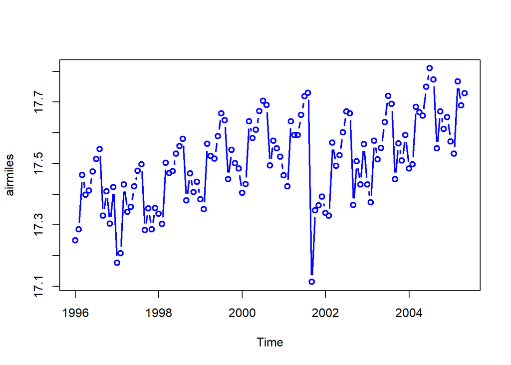

```r
wind <- window(log(airmiles),end=c(2001,8))
wind <- log(airmiles)
plot(wind, col = "blue",type = "b",lwd =2)
```

Хорошо заметен линейный тренд уберем его дифференцированием и построим ACF

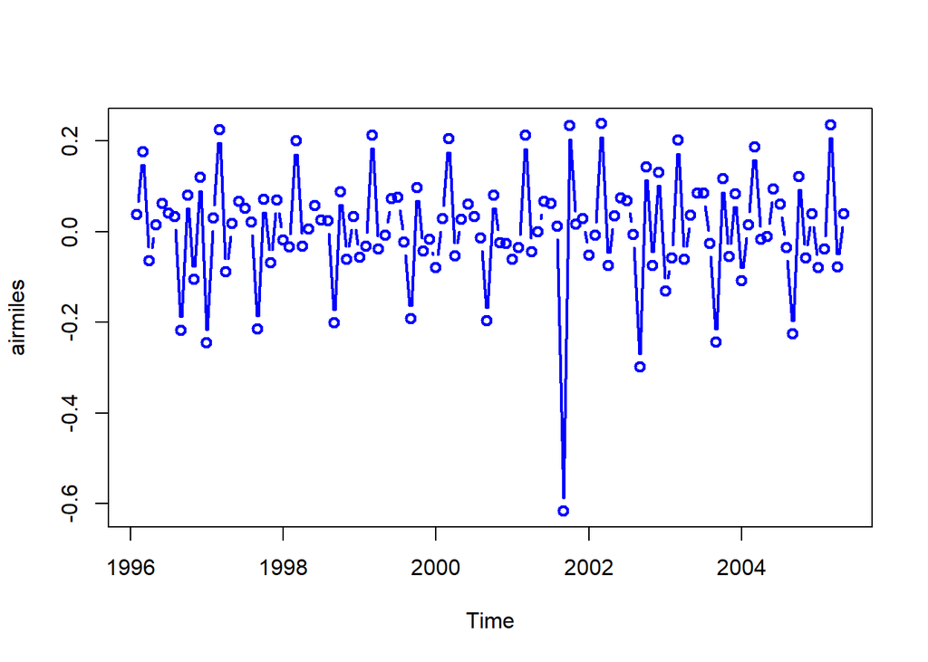

```r
dwind <- diff(wind)
plot(dwind, col = "blue",type = "b",lwd =2)
```

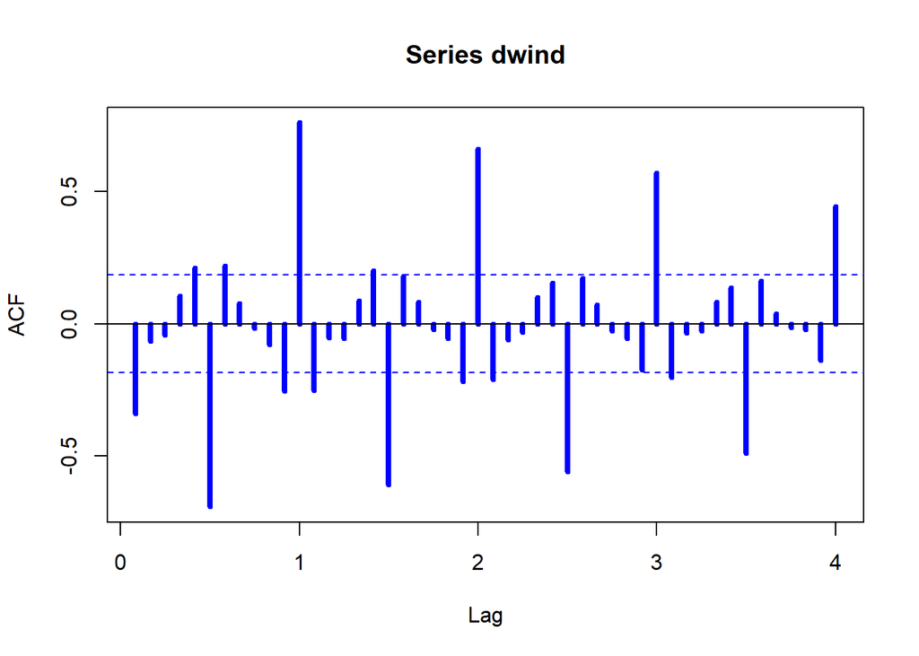

```r
acf(dwind,lag.max=48,lwd =4,col = "blue")
```

через каждые 12 задерержек (лагов) ACF медленно затухает, что говорит о наличии тренда в сезонности, уберем и его сезонным дифференцированием и опять построим ACF.

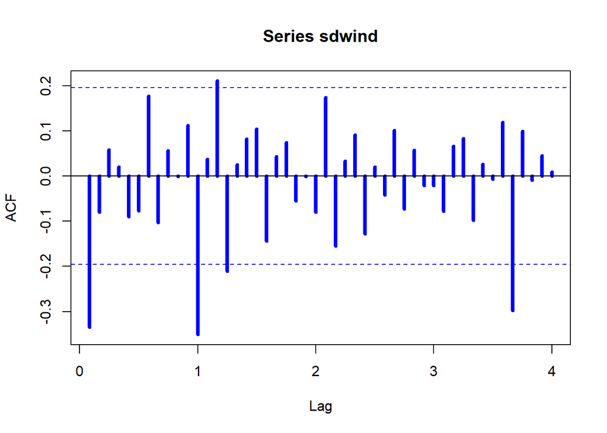

```r
sdwind <- diff(dwind,12)
acf(sdwind,lag.max=48,lwd =4,col = "blue")
```

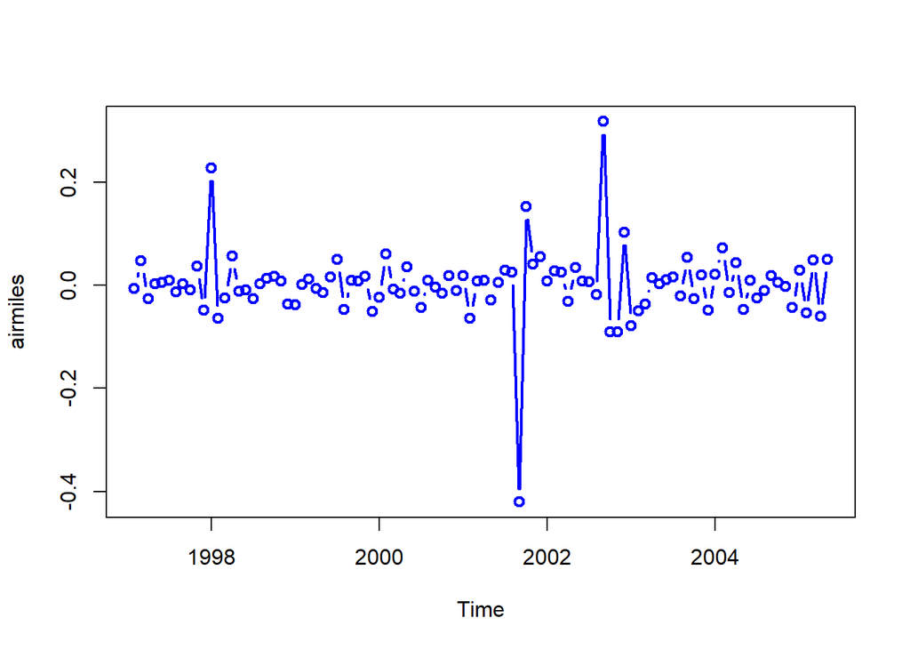

```r
plot(sdwind, col = "blue",type = "b",lwd =2)
```

```r
air.m1=arimax(log(airmiles),order=c(0,1,1),seasonal=list(order=c(0,1,1),period=12),xtransf=data.frame(I911=1*(seq(airmiles)==69),
I911=1*(seq(airmiles)==69)),transfer=list(c(0,0),c(1,0)),
xreg=data.frame(Dec97=1*(seq(airmiles)==12),
Jan98=1*(seq(airmiles)==13),Dec02=1*(seq(airmiles)==84)),
method='ML')
air.m1
```

```
##
## Call:
## arimax(x = log(airmiles), order = c(0, 1, 1), seasonal = list(order = c(0, 1,
##     1), period = 12), xreg = data.frame(Dec97 = 1 * (seq(airmiles) == 12), Jan98 = 1 *
##     (seq(airmiles) == 13), Dec02 = 1 * (seq(airmiles) == 84)), method = "ML",
##     xtransf = data.frame(I911 = 1 * (seq(airmiles) == 69), I911 = 1 * (seq(airmiles) ==
##         69)), transfer = list(c(0, 0), c(1, 0)))
##
## Coefficients:
##           ma1     sma1   Dec97    Jan98   Dec02  I911-MA0  I911.1-AR1
##       -0.3825  -0.6499  0.0989  -0.0690  0.0810   -0.0949      0.8139
## s.e.   0.0926   0.1189  0.0228   0.0218  0.0202    0.0462      0.0978
##       I911.1-MA0
##          -0.2715
## s.e.      0.0439
##
## sigma^2 estimated as 0.0006721:  log likelihood = 219.99,  aic = -423.98
```

Функция arimax методом максимального правдоподобия производит оценку модели вида

$\Delta^d\Delta_S^D\phi_p(B)\Phi_P(B^s)y_t= m_t+\theta_q(B)\Theta_Q(B^s)\epsilon_t$

где

$\phi_p(B)=1-\phi_1B-...-\phi_pB^p$

$\Phi_P(B^s)=1-\Phi_1B^s-...-\Phi_PB^{sP}$

$\theta_q(B)=1-\theta_1B-...-\theta_qB^p$

$\Theta_Q(B^s)=1-\Theta_1B^s-...-\Theta_QB^{sQ}$

характеристические полиномы авторегресии скользящего среднего, не сезонной и сезонной части соответственно. $\Delta =1-B$ и $\Delta_S= 1-B^S$ операторы не сезонной и сезонной разности соответсвено, $d,D$ - порядки несезонных и сезонных разностей.

В функции arimax параметры $p,q,d$ и $P,Q,D$ и период сезонности $s$ задаются так order=c(0,1,1),seasonal=list(order=c(0,1,1),period=12).

$m_t$ это матрица столбцы которой $m_t= (m_{1,t},m_{2,t},m_{3,t},m_{4,t})$ имеют длину равную длины ряда - модели собственно 4 интервенций: сентябрь 2001-порядковый номер в ряде 69;

декабрь 2002-порядковый номер в ряде 84.

Последние три интервенции имеют характер мгновенного вброса, поэтому модель для них выглядит просто

$$m_{k,t}= \beta_kP_{k,t}(T)$$
,$k=2,3,4; T = 12,13,84$$

Эти три модели интервенций (вбросов) в функции задаются в R коде параметром xreg=data.frame(Dec97=1*(seq(airmiles)==12),Jan98=1*(seq(airmiles)==13),Dec02=1*(seq(airmiles)==84))

Матрица $P_{k,t}(T), k = 2,3,4;$

```r
xreg=data.frame(Dec97=1*(seq(airmiles)==12),Jan98=1*(seq(airmiles)==13),Dec02=1*(seq(airmiles)==84))
xreg
```

```
##     Dec97 Jan98 Dec02
## 1       0     0     0
## 2       0     0     0
## 3       0     0     0
## 4       0     0     0
## 5       0     0     0
## 6       0     0     0
## 7       0     0     0
## 8       0     0     0
## 9       0     0     0
## 10      0     0     0
## 11      0     0     0
## 12      1     0     0
## 13      0     1     0
## 14      0     0     0
```

[output cut: 99 more lines]

Остается наиболее интересная интервенция, сентября 2001 года, ее задают в виде передаточной функции (transfer function) Модель передаточной функции

$y_t= \frac{u_m(B)}{v_l(B)}x_t+\frac{w_k(B)}{r_h(B)}P_t(T)$

$u_m(B)= u_0-u_1B-...-u_mB^m$

$v_l(B)= 1-v_1B-...-v_lB^l$

$w_k(B)= w_0-w_1B-...-w_kB^k$

$r_h(B)= 1-r_1B-...-r_hB^h$

Обратите внимание на свободный член в полиномах $u_m(B),w_k(B)$. Он не равен 1, как мы привыкли видеть в ARMA моделях.

$y_t= u_0x_t+\frac{w_0}{1-r_1B}P_t(T)$

полагая $x_t=P_t(T)$,а $y_t= m_t$как раз и получим требуемую модель интервенции

$m_t= \omega_0 P_t(T)+\frac{\omega_1}{1-\omega_2B}P_t(T)$

Сравним исходные данные с значениями, полученными по модели.

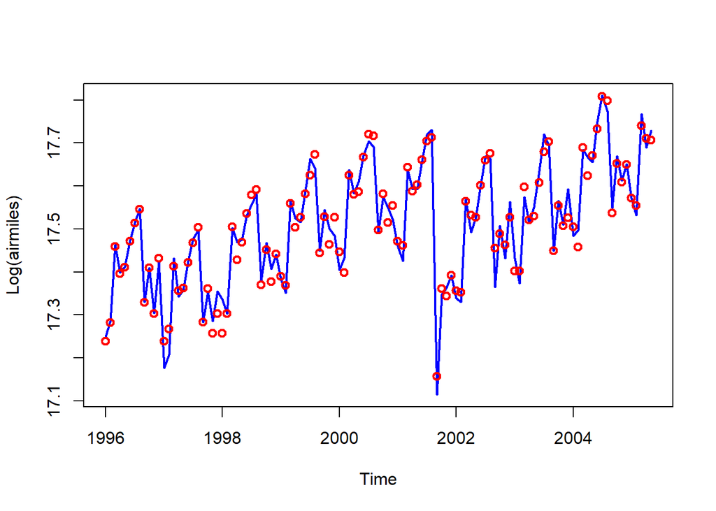

```r
plot(log(airmiles),ylab='Log(airmiles)',col= "blue",lwd =2)
points(fitted(air.m1),col= "red",lwd =2)
```

Посмотрим на графический фид модели интервенции, которую оценили

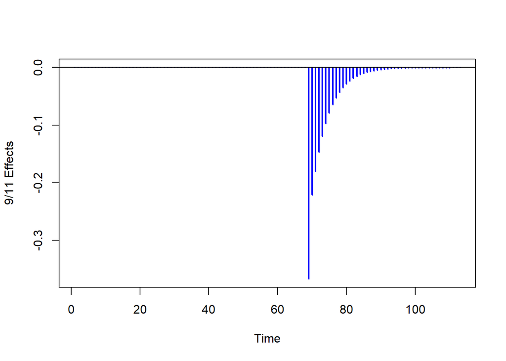

```r
Nine11p=1*(seq(airmiles)==69)
inter0911<-Nine11p*(-0.0949)+ filter(Nine11p,filter=.8139,method='recursive', side=1)*
(-0.2715)
plot(inter0911,ylab='9/11 Effects',
type='h',col = "blue",lwd = 2);
abline(h=0)
```

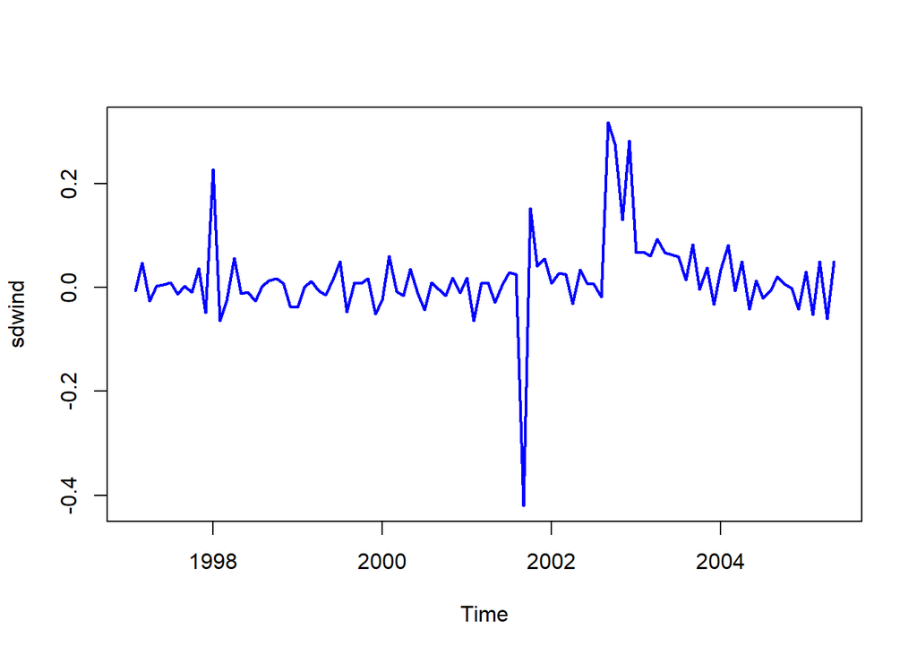

```r
inter0911 = ts(inter0911,frequency = 12,start= c(1997,2))
withoutinter0911= sdwind-inter0911
plot(withoutinter0911,col = "blue",type = "l",lwd = 2)
```

## пример с производством кока-колы

Чмтаем данные

```
##      pends  anntime  value
## 1 19830331 19830426 0.0375
## 2 19830630 19830725 0.0492
## 3 19830930 19831102 0.0463
## 4 19831231 19840214 0.0379
## 5 19840331 19840419 0.0425
## 6 19840630 19840720 0.0583
```

Момент интервенции

```r
(Intervention.Time <- 1983+MT*0.25)
```

```
## [1] 1998.5
```

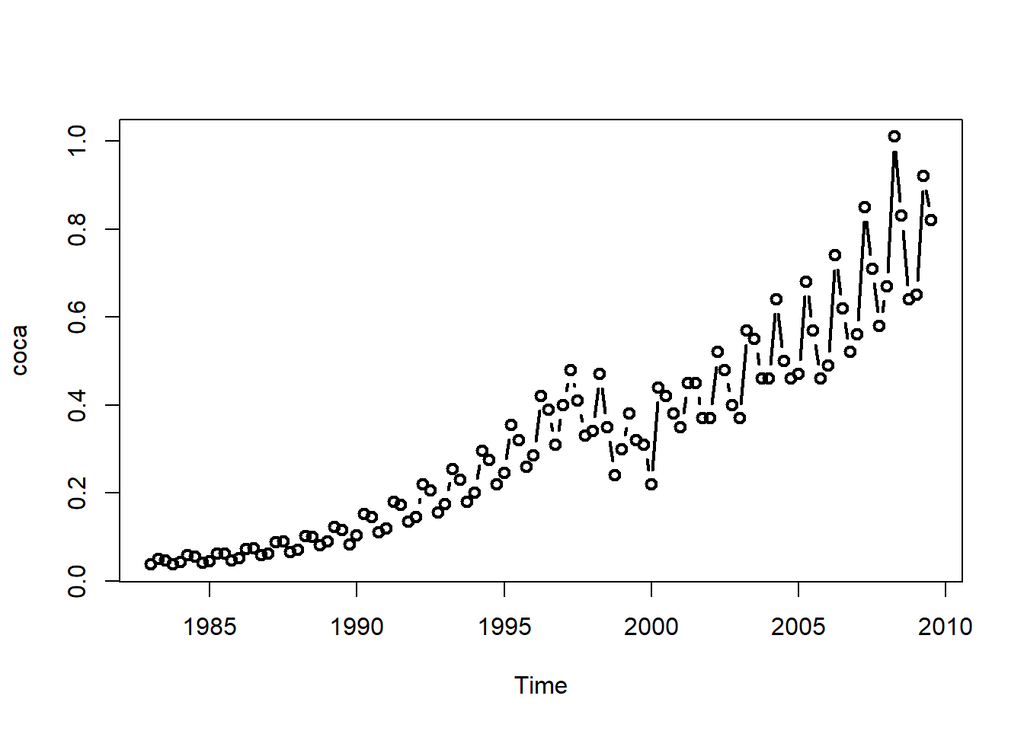

```r
par(mfrow = c(1, 1), cex = 1.0)
coca <- ts(dat$value,start=1983,frequency =4)
plot(coca,type = "b",pch = 21,lwd = 2)
```

Берем натуральный логарифм

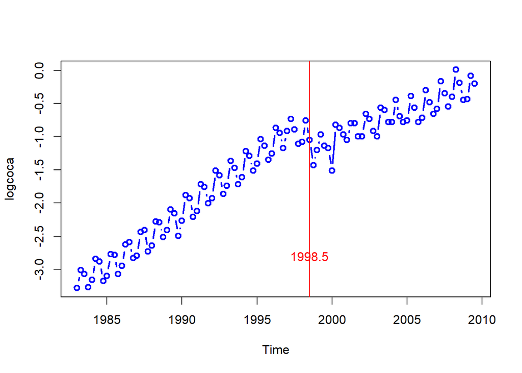

```r
logcoca <- log(coca)
plot(logcoca, col = "blue",type = "b",lwd =2)
abline(v = Intervention.Time,col = "red",lwd = 1)
text(x = Intervention.Time,y = -2.8,labels = as.character(Intervention.Time),col = "red")
```

Для удаления тренда возьмем несезонные и сезонные разности

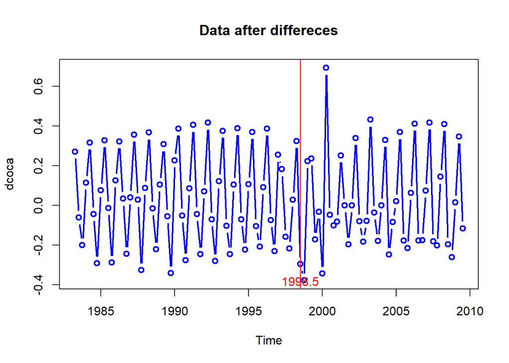

```r
dcoca <- diff(logcoca)
ddcoca <- diff(dcoca,4)
plot(dcoca, col = "blue",type = "b",lwd =2, main = "Data after differeces")
abline(v = Intervention.Time,col = "red",lwd = 1)
text(x = Intervention.Time,y = -0.38,labels = as.character(Intervention.Time),col = "red")
```

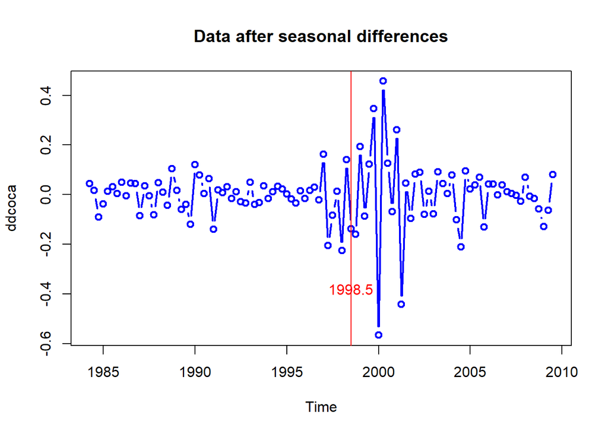

```r
plot(ddcoca, col = "blue",type = "b",lwd =2, main = "Data after seasonal differences")
abline(v = Intervention.Time,col = "red",lwd = 1)
text(x = Intervention.Time,y = -0.38,labels = as.character(Intervention.Time),col = "red")
```

Момент интервенции

```r
Intervention.Time
```

```
## [1] 1998.5
```

### SARMA модель идентификация

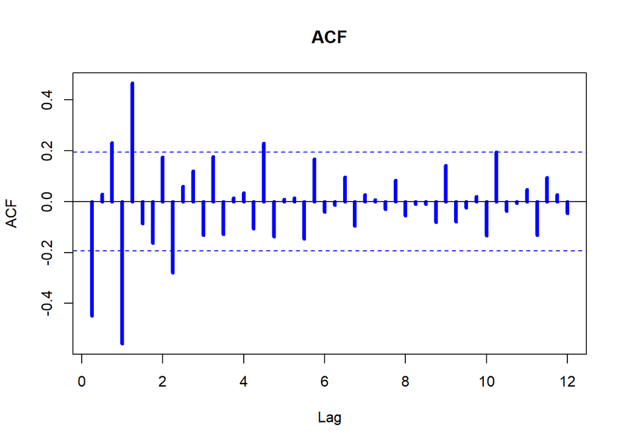

```r
acf(ddcoca,lag.max=48,lwd =4,col = "blue",main = "ACF")
```

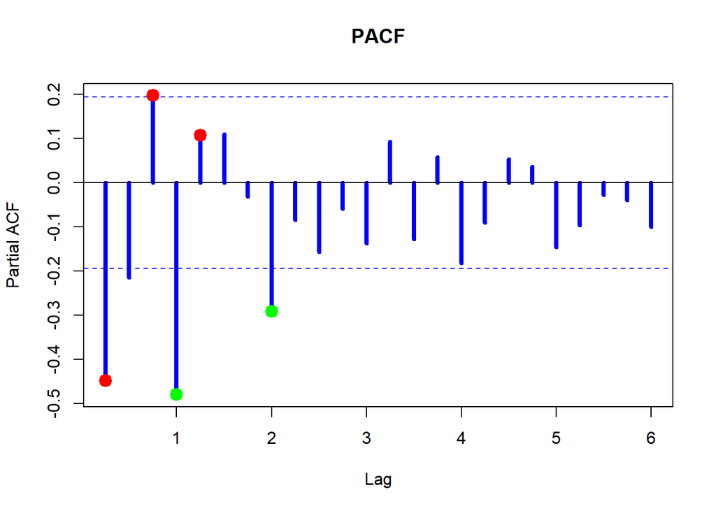

```r
pa <-  pacf(ddcoca,lag.max=24,lwd = 4,col = "blue",main = "PACF")
modelpacf.y <- c(pa$acf[1],pa$acf[3],pa$acf[5])
modelpacf.x <- c(0.25,0.75,1.25)
smodelpacf.y <- c(pa$acf[4],pa$acf[8])
smodelpacf.x <- c(1,2)
points(modelpacf.x,modelpacf.y,col = 'red',pch = 20,lwd = 8)
points(smodelpacf.x,smodelpacf.y,col = 'green',pch = 20,lwd = 8)
```

SARIMA Модель.

Сезонный SAR порядок $P=2$,

несезонный AR порядок $p = 1$,

несезонные разности $d = 1$.

сезонные разности $D = 1$.

### SARIMA и модель Интервенции оценивание

Оценка модели
$$y_t= m_t+N_t$$
где $m_t$ - модель Интервенции,

$N_t$ - SARIMA модель $(p,d,q)*(P,D,Q)_{4}$

с несезонным и сезонным AR порядками
$$p= 1,P= 2$$
с несезонным и сезонным MA порядками
$$q=0,Q=0$$
с несезонным и сезонными порядками разностей
$$d = 1,D=1$$

Будем задавать модель интервенции $m_t$ через модель передаточных функций

Общий вид модели передаточной функции
$$y_t= \frac{u_m(B)}{v_l(B)}x_t+\frac{w_k(B)}{r_h(B)}S_t(T)$$

где $u_m(B),v_l(B),w_k(B),r_h(B)$ полиномы порядка $m,l,k,h$ соответственно.

$$u_m(B)= u_0-u_1B-...-u_mB^m$$
$$v_l(B)= 1-v_1B-...-v_lB^l$$
$$w_k(B)= w_0-w_1B-...-w_kB^k$$
$$r_h(B)= 1-r_1B-...-r_hB^h$$

Мы зададим передаточную функцию в виде `transfer=list(c(0,0),c(1,0))` следовательно

$$u_m(B)= u_0$$
$$v_l(B)= 1$$
$$w_k(B)= w_0$$
$$r_h(B)= 1-r_1B$$

Таким образом модель интервенции будет
$$m_t= u_0x_t+\frac{w_0}{1 - r_1B}S_t(T)$$
где $S_t(T)$ функция ступени

т.е если $t >= T$ тогда $S_t(T)=1$ иначе $0$.

```r
iAR<- 1
(I1<- 1*(seq(coca)>=MT))
```

```
##   [1] 0 0 0 0 0 0 0 0 0 0 0 0 0 0 0 0 0 0 0 0 0 0 0 0 0 0 0 0 0 0 0 0 0 0 0 0 0
##  [38] 0 0 0 0 0 0 0 0 0 0 0 0 0 0 0 0 0 0 0 0 0 0 0 0 1 1 1 1 1 1 1 1 1 1 1 1 1
##  [75] 1 1 1 1 1 1 1 1 1 1 1 1 1 1 1 1 1 1 1 1 1 1 1 1 1 1 1 1 1 1 1 1 1
```

```r
coca.sarima=arimax(log(coca),
               order=c(1,1,0),
               seasonal=list(order=c(2,1,0),period=4),
               xtransf=data.frame(I1,I1),
              transfer=list(c(0,0),c(iAR,0)),method='ML')

AIC(coca.sarima)
```

```
## [1] -205.2352
```

### Оценка модели

Коэффициенты модели

```r
coca.sarima$coef
```

```
##        ar1       sar1       sar2     I1-MA0   I1.1-AR1   I1.1-MA0
## -0.4566840 -0.7868270 -0.2150182  1.4992227  0.2068143 -1.5798213
```

где $u_0=$

```
##   I1-MA0
## 1.499223
```

$w_0=$

```
##  I1.1-MA0
## -1.579821
```

$r_1=$

```
##  I1.1-AR1
## 0.2068143
```

Мы задали `xtransf=data.frame(I1, I1)’ следовательно $x_t = S_t(T)$,
и в итоге наша модель примет вид
$$y_t= u_0S_t(T)+\frac{w_0}{1 - r_1B}S_t(T)$$

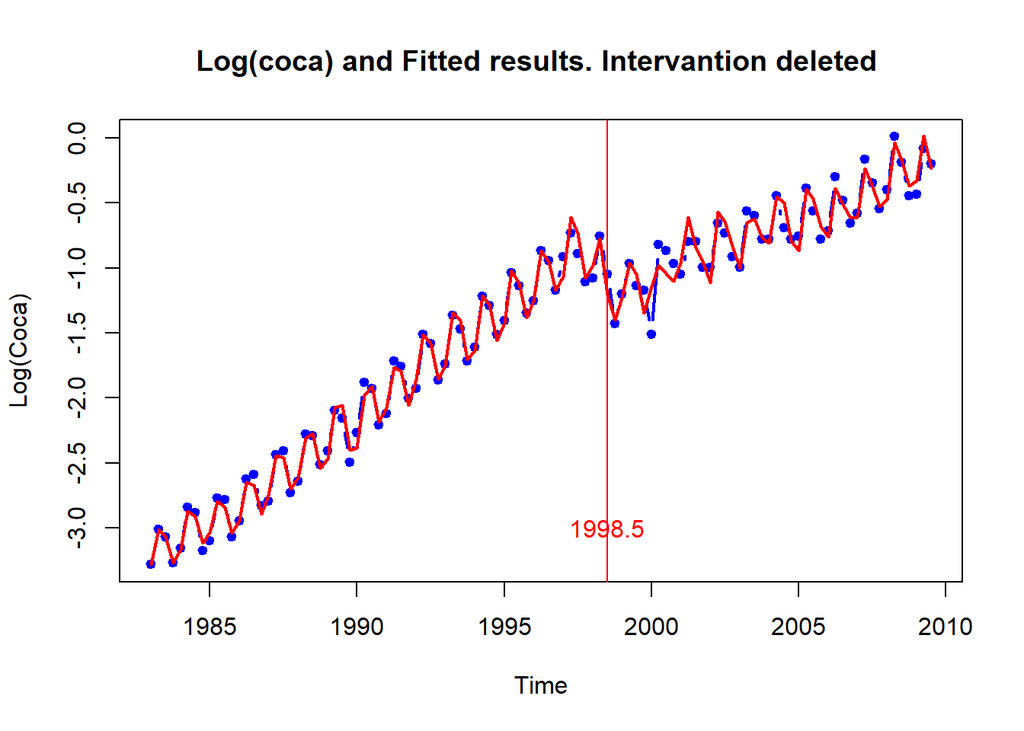

```r
plot(log(coca),type = "b", pch = 20,ylab='Log(Coca)',main = 'Log(coca) and Fitted results. Intervantion deleted ',col= "blue",lwd =2)
lines(fitted(coca.sarima),col= "red",lwd =2)
abline(v= Intervention.Time,col = "red",lwd = 1)
text(x = Intervention.Time,y = -3,labels = as.character(Intervention.Time), col = "red")
```

Остатки после удаления модели

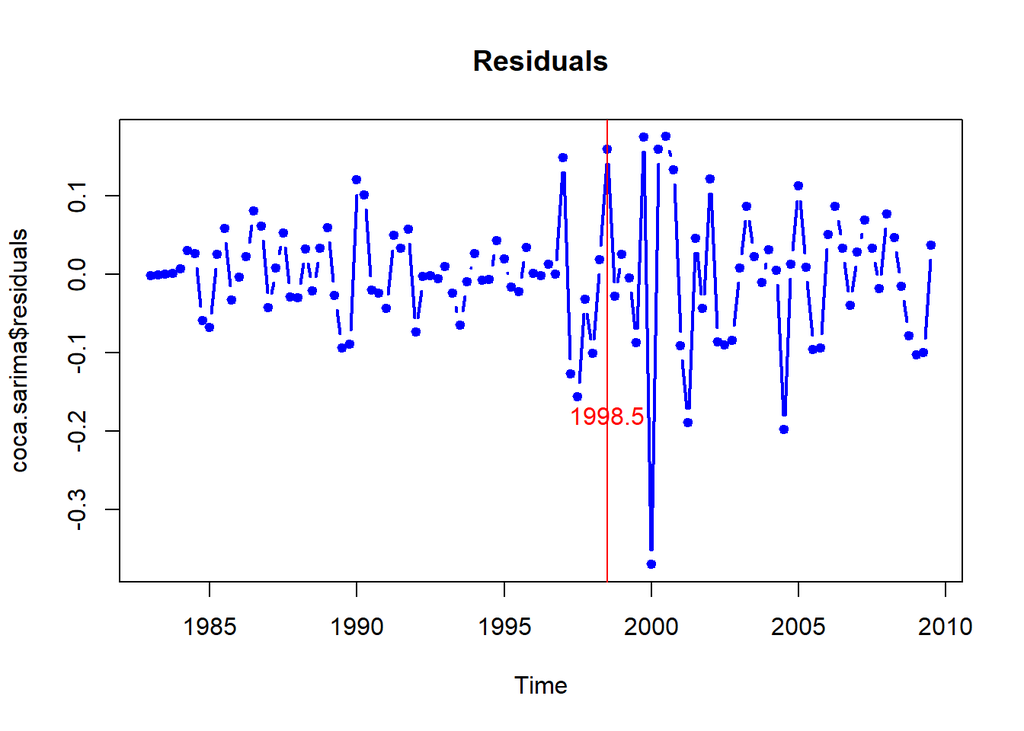

```r
plot(coca.sarima$residuals,type = "b",pch = 20,main = "Residuals",col = "blue",lwd = 2)
abline(v = Intervention.Time,col = "red",lwd = 1)
text(x = Intervention.Time,y = -0.18,labels = as.character(Intervention.Time),col = "red")
```

### Эффект интервенции

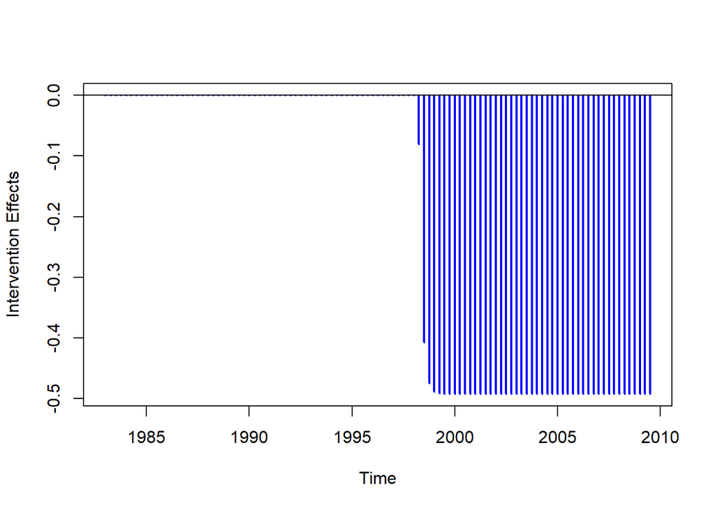

```r
inter1<-I1*u_0+ filter(I1,filter=r_1,method='recursive', side=1)*
(w_0)
inter1 <- ts(inter1,start = 1983,frequency = 4)
plot(inter1,ylab='Intervention Effects',
type='h',col = "blue",lwd = 2);
abline(h=0)
```

### Удаление модели из данных

Удалим модель интервенции с моментом интервенции

```r
 Intervention.Time
```

```
## [1] 1998.5
```

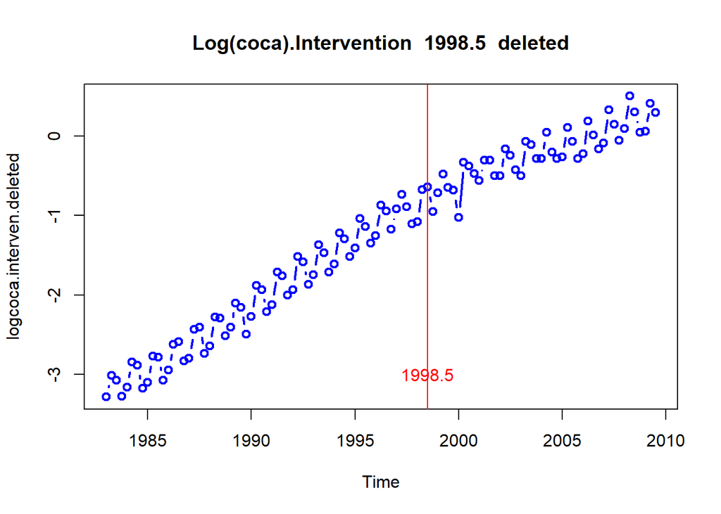

```r
logcoca.interven.deleted <- logcoca - inter1
plot(logcoca.interven.deleted,main = paste("Log(coca).Intervention ",Intervention.Time," deleted"), col = "blue",type = "b",lwd =2)
abline(v= Intervention.Time,col = "red",lwd = 1)
text(x = Intervention.Time,y = -3.0,labels = Intervention.Time,col = "red")
```

### Оценка второго момента интервенции

Все уравнения для второго момента остаются такими же. Но вторую интервенцию будем считать типи импульс `pulse` т.е. $P_t(T)=1$ если и только если $t = T$.

```r
MT2 <- 68
(Intervention.Time2 <- 1983+MT2*0.25)
```

```
## [1] 2000
```

```r
iAR<- 1
(I2<- 1*(seq(coca)==MT2))
```

```
##   [1] 0 0 0 0 0 0 0 0 0 0 0 0 0 0 0 0 0 0 0 0 0 0 0 0 0 0 0 0 0 0 0 0 0 0 0 0 0
##  [38] 0 0 0 0 0 0 0 0 0 0 0 0 0 0 0 0 0 0 0 0 0 0 0 0 0 0 0 0 0 0 1 0 0 0 0 0 0
##  [75] 0 0 0 0 0 0 0 0 0 0 0 0 0 0 0 0 0 0 0 0 0 0 0 0 0 0 0 0 0 0 0 0 0
```

```r
coca.sarima2=arimax(logcoca.interven.deleted,
                   order=c(1,1,0),
                   seasonal=list(order=c(2,1,0),period=4),
                   xtransf=data.frame(I2,I2),
                   transfer=list(c(0,0),c(iAR,0)),method='ML')
I2
```

```
##   [1] 0 0 0 0 0 0 0 0 0 0 0 0 0 0 0 0 0 0 0 0 0 0 0 0 0 0 0 0 0 0 0 0 0 0 0 0 0
##  [38] 0 0 0 0 0 0 0 0 0 0 0 0 0 0 0 0 0 0 0 0 0 0 0 0 0 0 0 0 0 0 1 0 0 0 0 0 0
##  [75] 0 0 0 0 0 0 0 0 0 0 0 0 0 0 0 0 0 0 0 0 0 0 0 0 0 0 0 0 0 0 0 0 0
```

```r
coca.sarima2$coef
```

```
##         ar1        sar1        sar2      I2-MA0    I2.1-AR1    I2.1-MA0
## -0.19962805 -0.75999359 -0.22096001 -3.36012893 -0.08171462  3.48083400
```

### Эффект интервенции

```r
(u_0 <-coca.sarima2$coef[4])
```

```
##    I2-MA0
## -3.360129
```

```r
(r_1 <- coca.sarima2$coef[5:(5+iAR-1)])
```

```
##    I2.1-AR1
## -0.08171462
```

```r
(w_0<-coca.sarima2$coef[(5+iAR)])
```

```
## I2.1-MA0
## 3.480834
```

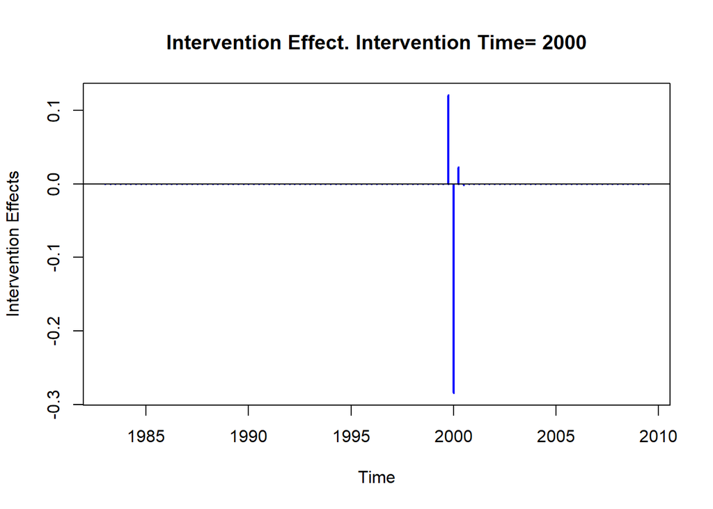

```r
p2=1*(seq(coca)==MT2)
inter2<- p2*u_0+ filter(p2,filter=r_1,method='recursive', side=1)*
  (w_0)
inter2 <- ts(inter2,start = 1983,frequency = 4)

plot(inter2,main = paste("Intervention Effect. Intervention Time=",Intervention.Time2), ylab='Intervention Effects',
     type='h',col = "blue",lwd = 2)
abline(h=0)
```

Удаляем вторую модель из данных

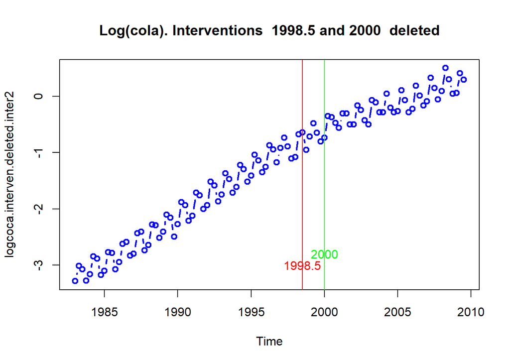

```r
logcoca.interven.deleted.inter2<- logcoca.interven.deleted - inter2

plot(logcoca.interven.deleted.inter2,main = paste("Log(cola). Interventions ",Intervention.Time,"and",Intervention.Time2, " deleted"), col = "blue",type = "b",lwd =2)
abline(v= Intervention.Time,col = "red",lwd = 1)
abline(v= Intervention.Time2,col = "green",lwd = 1)
text(x = Intervention.Time,y = -3,labels = as.character(Intervention.Time), col = "red")
text(x = Intervention.Time2,y = -2.8,labels = as.character(Intervention.Time2), col = "green")
```

Результат после удаления двух моделей интервенций

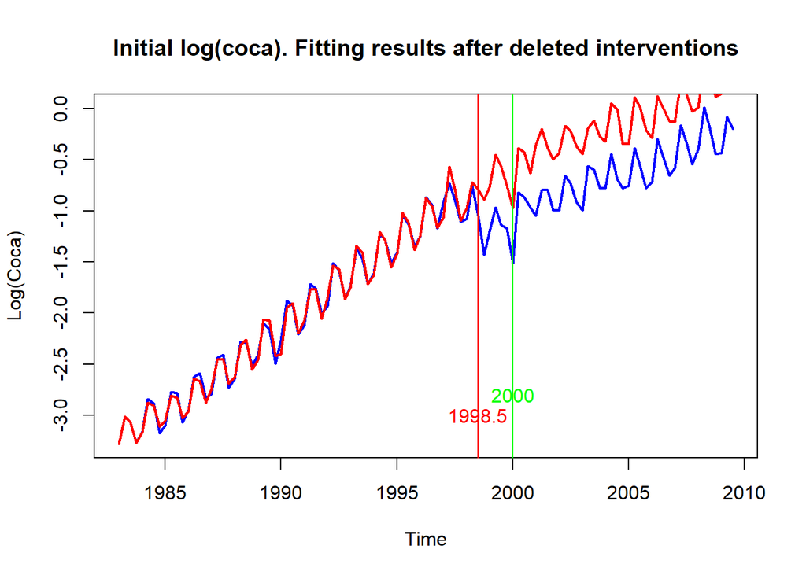

```r
plot(log(coca),type = "l", pch = 20,ylab='Log(Coca)',main = 'Initial log(coca). Fitting results after deleted interventions',col= "blue",lwd =2)
lines(fitted(coca.sarima2),type = "l",pch = 20,col= "red",lwd =2,lty = 1)
abline(v= Intervention.Time,col = "red",lwd = 1)
abline(v= Intervention.Time2,col = "green",lwd = 1)
text(x = Intervention.Time,y = -3,labels = as.character(Intervention.Time), col = "red")
text(x = Intervention.Time2,y = -2.8,labels = as.character(Intervention.Time2), col = "green")
```

## Безработица в США. Количество первичных обращений за пособиями по безработице. Initial claims

Сначала получим данные по безработице с правительственного сайта США https://fred.stlouisfed.org/series/ICNSA и подготовим их csv файле

Читаем initial claims даенные из файла

```r
iclaims <- read.table("ICNSA.csv",header = T,sep=",")
iclaims$ICNSA <- iclaims$ICNSA/1000
head(iclaims)
```

```
##      ï..date   ICNSA
## 1 2000-01-01 439.912
## 2 2000-01-08 606.897
## 3 2000-01-15 442.494
## 4 2000-01-22 328.841
## 5 2000-01-29 332.740
## 6 2000-02-05 365.245
```

```r
dim(iclaims)
```

```
## [1] 1111    2
```

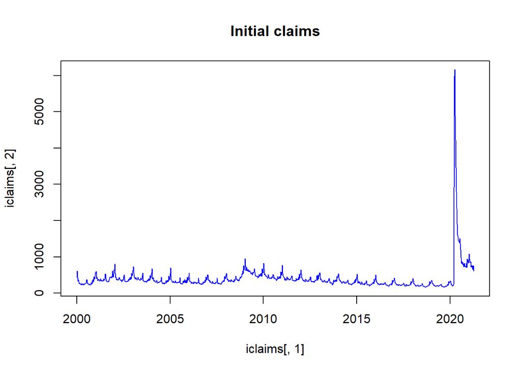

```r
iclaims[,1] <- as.Date(iclaims[,1],tryFormats = c("%Y-%m-%d", "%Y/%m/%d"),optional=T)
matplot(iclaims[,1],iclaims[,2],type='l',col = 'blue',main = 'Initial claims')
```

Initial claims данные содержат мощный рост в марте 2020 года, вызванный пандемией коронавирусной инфекцией в США.

## Пандемия коронавируса в США

Будем исследовать период с 2019-05-04 до 2021-04-10.

```r
n <- dim(iclaims)[1]
startdate<-'2019-05-04'
enddate<-'2021-04-10'
(n.start<- which(iclaims[,1]==startdate))
```

```
## [1] 1010
```

```r
(n.end<- which(iclaims[,1]==enddate))
```

```
## [1] 1111
```

```r
nn<-n.end-n.start+1
int.claims <- iclaims[n.start:n.end,]
```

Взрывной рост заболеваемости случился 2020-03-21. Эту дату отметим как сосент интервенции в росте числа безработных.

```r
Intervention.Time <- as.Date("2020-03-21")
(iT <- which(int.claims[,1]==Intervention.Time ))
```

```
## [1] 47
```

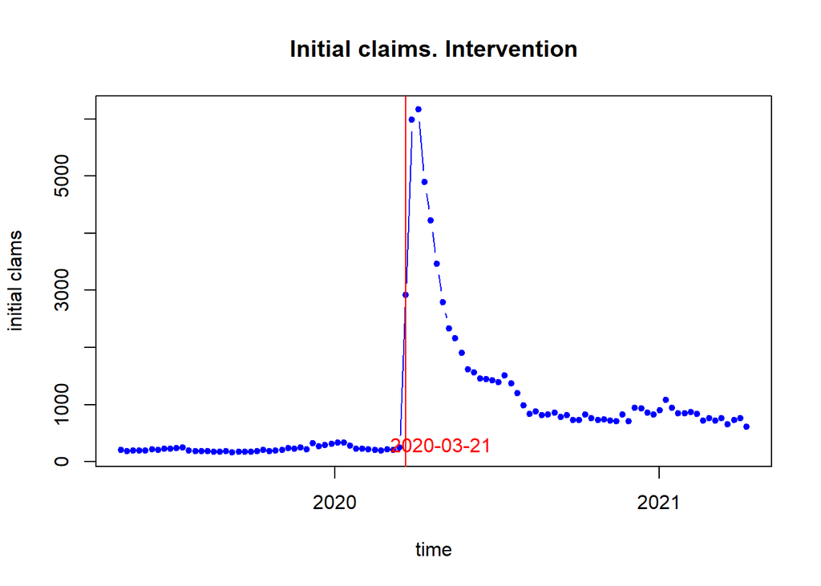

```r
matplot(int.claims[,1],int.claims[,2],type='b',main='Initial claims. Intervention',col = "blue",pch = 20,xlab="time",ylab="initial clams")
abline(v = Intervention.Time,col = "red",lwd = 1)
text(x = Intervention.Time+40,y = 300,labels = as.character(Intervention.Time),col = "red")
```

Идентифицируем ARMA модель к данным по безработице непосредственно перед моментом интервенции и оценим предложенную модель.

В качестве модели передаточной функции возьмем следующую модель

$$m_t= u_0S_t(T)+\frac{\omega_0+\omega_1B+...\omega_7B^7}{1-r_1B-r_2B^2}S_t(T)$$
где $S_t(T)$ - функция типа ступень. Момент интервенции $T$, т.e. $S_t(T)=0,t< T$ и $S_t(T)=1$ иначе.

Идентифицируем ARMA модель непосредственно перед интервенцией

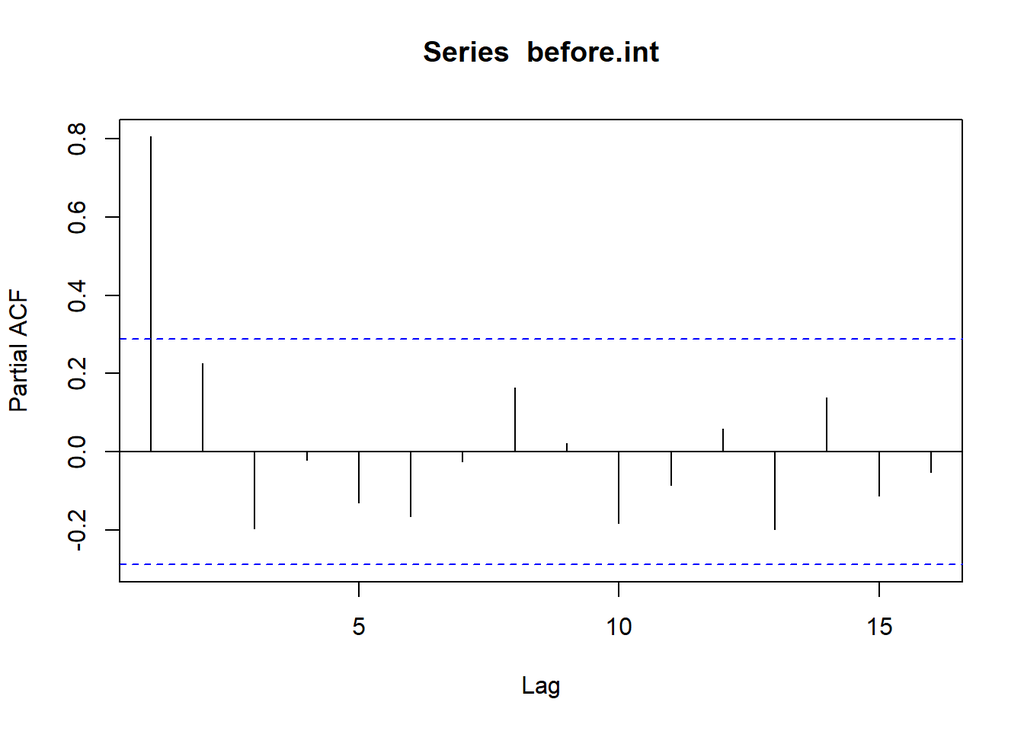

```r
before.int = int.claims[1:iT-1,2]
pacf(before.int)
```

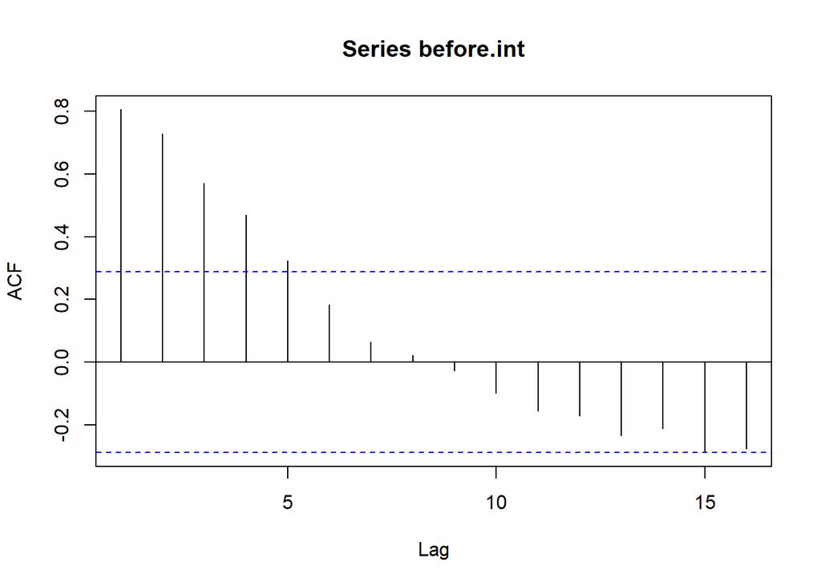

```r
acf(before.int)
```

Пусть это будет AR порядка 1 и MA порядка 0.

Оценим параметры передаточной функции, в которой порядок типа AR равен 2 и порядок типа MA равен 3.

```r
p<-2
q<-3
```

Функция для моделирования модели интервенции вида
$$m_t= u_0S_t(T)+\frac{\omega_0+\omega_1B+...\omega_7B^q}{1-r_1B-...-r_pB^p}S_t(T)$$

```r
inter.sim <- function(n,u,ar,ma,iT,isPulse)
{
  p <- length(ar)
  q <- length(ma)
  vec <-1:n
  if (isPulse)
    interven=1*(seq(vec)==iT)
  else
    interven=1*(seq(vec)>=iT)

  inter <-stats::filter(interven,filter=ar,
                        method='recursive', side=1)*  ma[1]
  for (i in 2:q)
  {
    if (isPulse)
      interven.i <- 1*(seq(vec)==(iT+i-1))
    else
      interven.i <- 1*(seq(vec)>=(iT+i-1))

    inter.i <-stats::filter(interven.i,filter=ar,
                            method='recursive', side=1)*  ma[i]
    inter <- inter+inter.i
  }
  return (inter+u*interven)
}
```

Функция для вычисления суммы квадратов остатков
$$RSS = \sum_{i=1}^T(x_t-m_t)^2$$

```r
fn <- function(param,x,pp,qq,int.time,isPulse)
{
  nParam<- length(param)
  u0 <- param[1]
  ar <- param[2:(pp+1)]
  ma <- param[(2+pp):nParam]
  n <- length(x)
  m <- mean(x[1:(int.time-1)])
  interven <- inter.sim(n,u0,ar,ma,int.time,isPulse )+m
  res <-sum((x - interven)^2)
  return (res)
}
```

Функция для минимизации $RSS$ по параметрам $u_0,\omega_0,\omega_1, ...\omega_q,r_1,...,r_p$ модели интервенции

```r
estimate.interven<- function(x,transfer,int.time,isPulse)
{
  pp<- transfer[1]
  qq<- transfer[2]
  t.order <- pp+qq+2
  param <- rep(0.2,t.order)
  res <- optim(param,fn,gr=NULL,x=x,pp = pp,qq ==qq,int.time= int.time, isPulse=isPulse, method="BFGS")
  listres <- list(u=res$par[1],ar = res$par[2:(pp+1)],ma   =res$par[(2+pp):t.order])
  return (listres)
}
```

Оценим параметры модели для модели интервенции типа ступень

```r
isPulse<-FALSE
res<-estimate.interven(int.claims[,2],c(p,q),iT,isPulse)
```

Посмотрим на результаты оценки параметров

параметр $u_0$

```r
(u0<-res$u)
```

```
## [1] 1892.313
```

Параметры передаточноей функции типа авторегрессии $r_1,r_2$

```r
(ar<-res$ar)
```

```
## [1] 0.5322218 0.2258301
```

Параметры передаточноей функции типа скользящего среднего $\omega_0,\omega_1,...,\omega_3$e

```r
(ma<-res$ma)
```

```
## [1]   802.8146  2636.4505 -1660.1075 -2093.0127
```

!!!Внимание !!! Важно проверить стационарность оцененной модели передаточной функции. Это определяется AR частью модели. Здесь воспользуемся стандартной процедурой вычисления корней характеристического полинома и проверкой, что по модулю они превосходят 1.

```r
AR.polynom <- c(1,-ar)
root<-polyroot(AR.polynom) # solve the polynomial equation
(rmin <-min(abs(root)))
```

```
## [1] 1.233407
```

```r
if (rmin<=1)
{
  print('!!!WARNING. AR part of the trunsfer function is not stationary')
  print('May be problems in prediction' )
}
```

Определим уровень безработицы до начала пандемии.

```r
(intervention.level <- mean(int.claims[as.integer(iT/2):(iT-1),2]))
```

```
## [1] 242.0214
```

Смоделируем оцененную модель интервенции

```r
interven <- inter.sim(nn,u0,ar,ma,iT,isPulse )
```

Посмотрим на графике модель и оригинальные данные

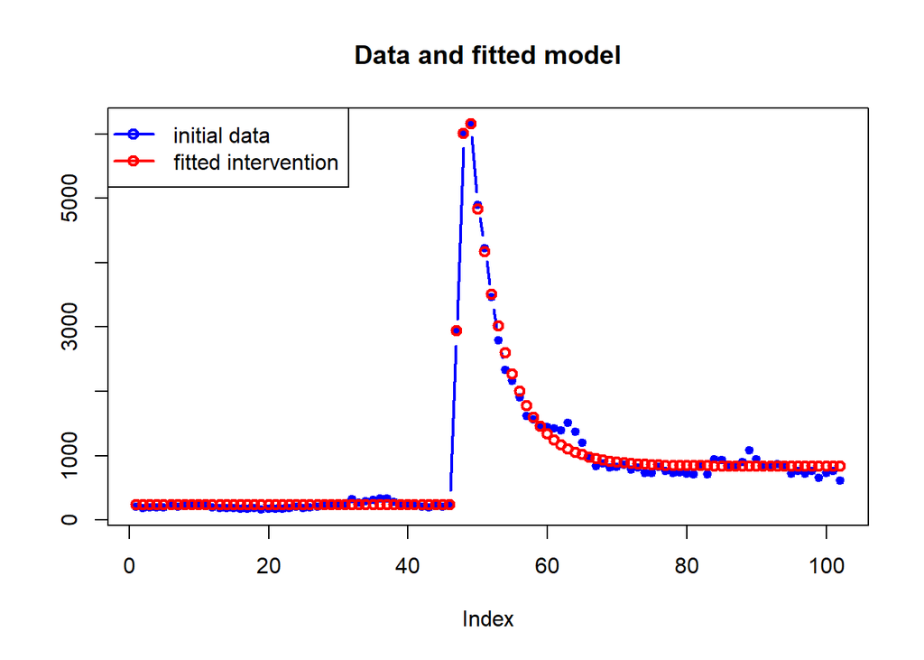

```r
plot(int.claims[,2],type= 'b',pch=20,ylab='',col= "blue",lwd =2,main = "Data and fitted model")
points(interven+intervention.level,pch = 21,col= "red",lwd =2)
legend("topleft",c("initial data","fitted intervention"),pch = 21,col = c("blue","red"),lwd =2)
```

### Эффект интервенции

Нарисуем полученную модель $m_t$.

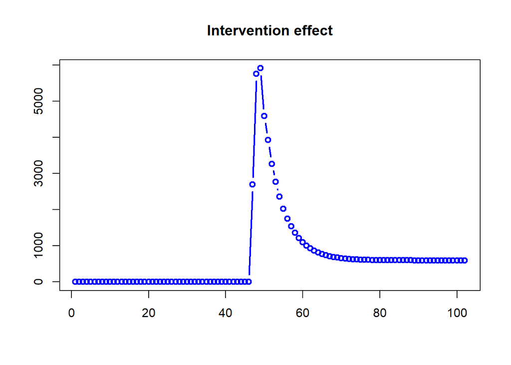

```r
matplot(interven,ylab='',main ='Intervention effect',
        type='b',pch = 21,col = c("blue"),lwd = 2)
```

Уберем эффект интервенции и оригинальных данных

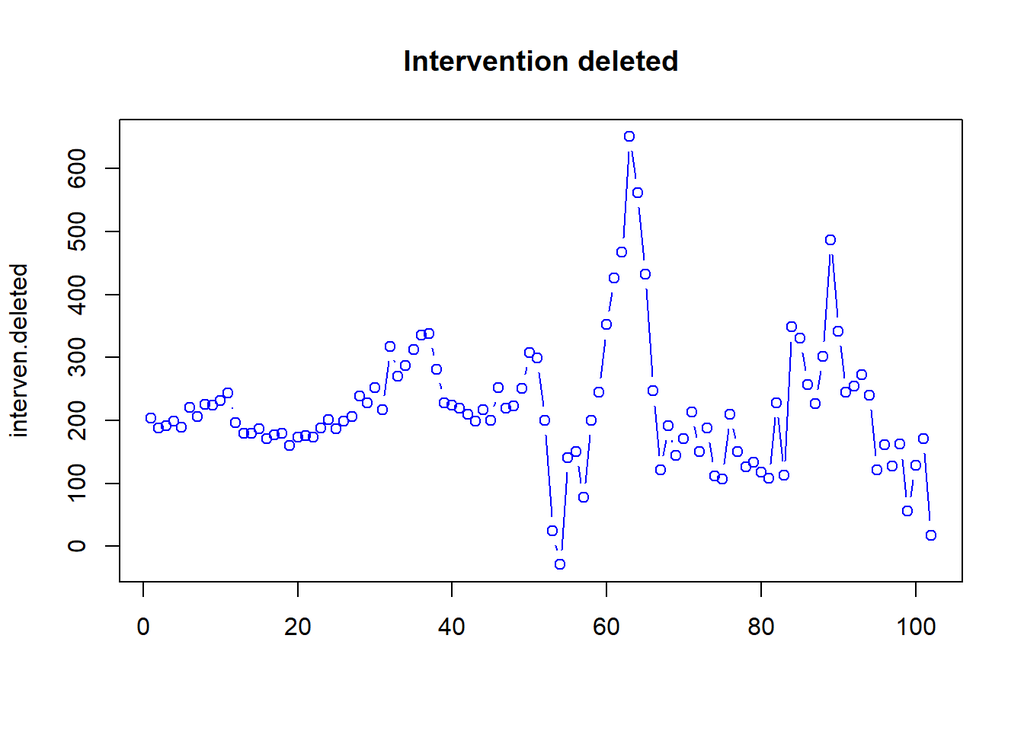

```r
interven.deleted<-int.claims[,2] - interven
matplot(interven.deleted,type = "b",pch = 21,col="blue",main = "Intervention deleted")
```

Посмотри на данные с удаленным еффектом интервенции

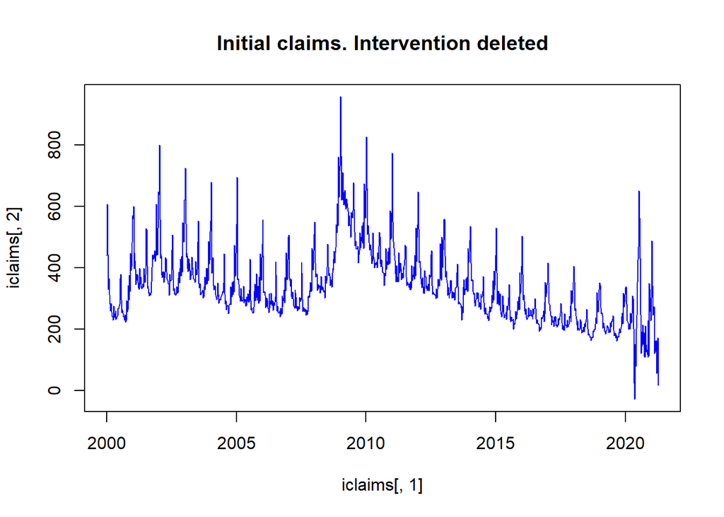

```r
iclaims[ n.start:n.end,2] <-interven.deleted
matplot(iclaims[,1],iclaims[,2],type='l',main='Initial claims. Intervention deleted',col = "blue")
```

Посмотрим на разности данных без интервенции.

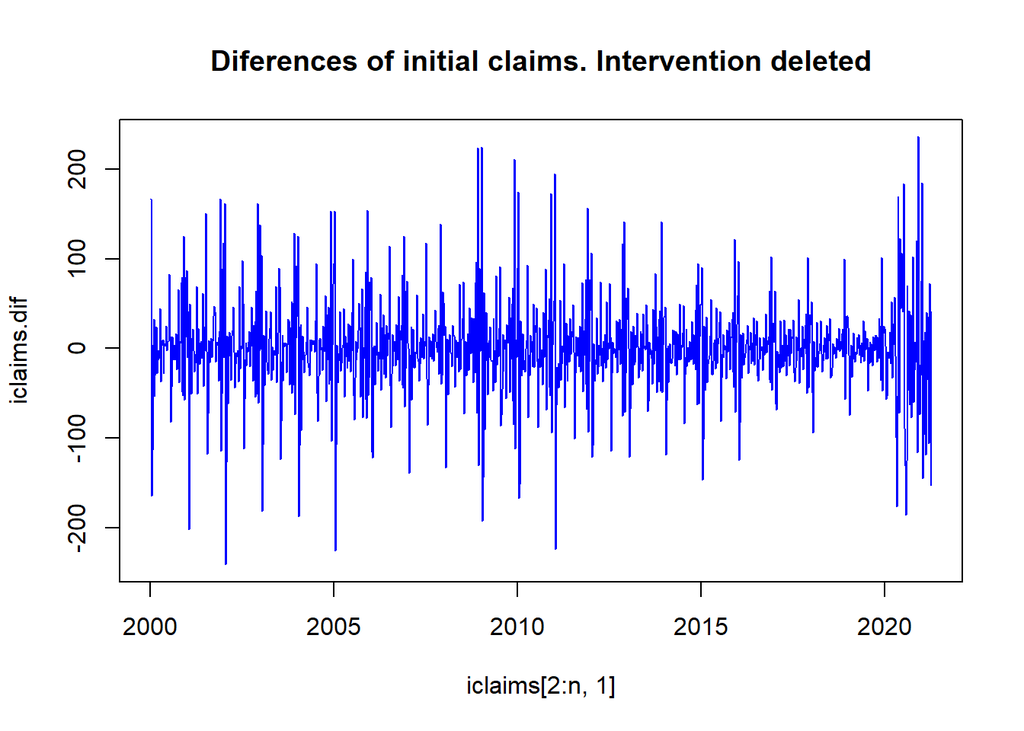

```r
 iclaims.dif <-diff(iclaims[,2])

matplot(iclaims[2:n,1],iclaims.dif,type='l',main='Diferences of initial claims. Intervention deleted',col = "blue")
```

Аналогично можно еще одну интервенцию убрать из модели, но не будем это делать из-за экономии.